# Substantive, particular, and statistical hypotheses in corpus linguistics

Roland Schäfer, Friedrich-Schiller-Universität Jena

2024

# 1 How to find things out in historical sociolinguistics (and agriculture)

## 1.1 The background: main hypotheses and purpose in Walkden et al. (2023)

The *Transactions of the Philological Society* recently published Walkden et al. (2023), a paper that aims to support an established theory from the area of sociolinguistic typology. Based on Trudgill (2011) and other works by Peter Trudgill, Walkden et al. (2023, 546–47) assume that there is a fundamental distinction between long-term language contact where change is introduced primarily through child bilingualism and short-term language contact characterised by adult L2 speakers. Details aside, there is an assumed tendency that the former leads to complexifications in the affected language and the latter to simplifications. Then, Walkden et al. (2023, 548–50) contrast existing approaches to support this type of theory: the *typological* approach utilises linguistic databases to examine grammatical systems in situations of language contact at the population level; the *experimental* approach uses artificial language learning situations to simulate on an individual speaker level. While both are valid and important, the *historical corpus* approach complements them by allowing researchers to examine *when* certain linguistic changes occurred in a historical situation of language contact, and the progression of changes through the areal of the affected language should provide evidence that the change occurs predominantly and early in areas where language contact is most intense. The paper presents among other things three corpus studies of potentially contact-driven simplification (Walkden et al. 2023, 551–61). We will argue that Study 1 and Study 2 do not—as they are—provide strong evidence or evidence at all for this hypothesis if the data are analysed with some rigour. This is due to a series of commonplace but nonetheless insufficient ways of analysing corpus data that we have encountered over and over in contemporary corpus linguistics. As we will hopefully make absolutely clear, our critique is directed towards such methods per se and not at the authors of the paper under discussion or the theory they advocate. On the contrary, the authors have to be praised for making their data available freely and sustainably for reanalyses like ours, a practice that is not at all common even today.

We feel a disclaimer is in order. While the general advice is often *not* to write papers like the present one because they might be perceived as destructive, overly critical, and the sign of a cantankerous character, we decided to write this paper nonetheless. In fact, the situation is ideal for a critique of methods and general practices precisely because we do not work in any of the relevant fields (sociolinguistics, historical linguistics, dialectology) and we have never had any academic or personal contact with any of the authors or their co-workers.[^1] Also, the authors form a large team with a well-established tenured person having an impeccable third-party funding record as the first-name author. Therefore, we can credibly say that the purpose of this exercise is not to damage anybody’s reputation but rather to improve the overall quality of research in corpus linguistics of any type, including the quality of our own future work—as we certainly have learned from the re-analysis of the data.[^2] We do not believe that any of the hypotheses put forward in Walkden et al. (2023) is wrong or implausible, and we sincerely wish that further work provides reliable evidence supporting them. However, the paper under discussion most likely does not.

An important aspect of this is the use of statistical models in the paper, and we now turn briefly to statistical models in Section 1.2. Subsequently, we very briefly discuss the nature of hypothesis testing (Section 1.3), echelons of hypotheses (Section 1.4), and traditions of statistical inference (Section 1.5). This is not intended as an authoritative or exhaustive summary of the history of the philosophy of science or modern statistics. Rather, we included it in order to position ourselves at a certain coordinate in the epistemological landscape. In Section 2, we re-analyse the data sets of Study 1 and Study 2 from Walkden et al. (2023) before summarising our critique and proposing elements of a culture of sound data analysis in linguistics and philology in Section 3. Hence, readers only interested in the reanalysis of the data from Walkden et al. (2023) might skip to Section 2.

## 1.2 Statistical models in corpus linguistics

Maybe no other advanced statistical method has been popularised farther than generalised linear models (GLMs). A highly influential paper in the popularisation of GLMs was Bresnan et al. (2007), quickly followed by Baayen (2008), which provided an accessible introduction to GLMs for linguists, Gries (2013) being another text book that included GLMs. A few years later, Gries (2015) still called generalised linear *mixed* models (GLMMs)—an extension of GLMs to be discussed presently—underused, but it is fair to say that diverse variants of GLMs now firmly belong to the repertoire of statistics for corpus linguists. GLMs and their variants are related to regression, and they have a very simple purpose: they estimate how the variance in a set of variables (the *regressors*, *predictors*, *explanatory variables*, or *independent variables*) is mathematically related to the variance in another variable (the *response*, *outcome*, or *dependent variable*). Regressors might, for example, be the animacy of a dative object in an English sentence (a binary variable with potential values *animate* and *inanimate*) and the length of the object NP, a possible response being whether the dative shift occured in the sentence or not. The regressors *vary* (not all instances have the same value for *animacy* and *length*), and depending on their concrete values they have in a given sentence, some of the variance in the response *dative shift* can potentially be explained. One would not expect to be able to predict all cases of dative shift correctly, but by estimating the influence of the two regressors, one would certainly hope to make better predictions than by guessing. Statistical models allow us researchers to specify which regressors we expect to play a role, and then the *estimator*—a piece of maths usually implemented in software often much more complicated than the simple concept of such a model might sound—uses existing data such as thousands of sentences with dative objects for which we have annotated all actual values of the regressors to provide the best possible numerical estimates of their influence on the response.[^3] Often, the mere quantification of the influence exerted by the various regressors on the response is more valuable to researchers than the ability to make actual predictions of what some speaker of English might say or write in the next utterance.[^4] In order to understand how language works, we desire to know what influences the choices that speakers make, and how strongly they do so, expressed in numbers. Estimators for GLMs, GLMMs, etc. provide such numbers.

We would like to highlight out some relevant points just made. The model itself is (or ought to be) a causal model of what controls the variance in the response. A model is thus *specified* by researchers based on theoretical assumptions or previous knowledge acquired through measurement. The estimator *estimates the parameters of the model*, above all the numbers which encode the strength of the regressors’ influence on the response. Hence, we do not “run a model” in a piece of software (see Walkden et al. 2023, 558). Several questions immediately emerge: (i) How do the specification of the model and the estimation of its parameters ensure that the regressors encode *causal* influences. The answer is chillingly simple inasmuch as they absolutely do not in any way ensure this. One could also (with partial success and a certain precision) model the length of an NP based on whether it has undergone dative shift or not, completely reversing the causality. (ii) How do we decide whether the estimates of the regressors’ influences are actually relevant? The data fed into the estimator might be too little to reach the required representativity, or it might be biased (in corpus linguistics usually because of opportunistic sampling or because too few data are supposed to cover to large a population across time or space), or there might be sampling-related quirks in the data set (such as data from even just one text that is highly idiosyncratic compared to all other texts in the sample), or some effect might be really small and just relevant for a tiny subset of the data, etc. However, the estimator might come up with a number (like $\beta$=0.03, see below) that actually and correctly quantifies the influence of a regressor on the response given the available data. Still, that influence might be utterly irrelevant or spurious. Routinely, this question is tackled using Null-Hypothesis Significance Testing (NHST), a failed system (see among numerous others Ioannidis 2005; Gigerenzer 2004; Perezgonzalez 2015; Greenland et al. 2016; Munafò et al. 2017; Mayo 2018) to decide which measured statistical generalisations are *significant* and which are not. NHST is usually understood as a distorted hybrid of the philosophies of inference by Ronald Aylmer Fisher (Fisher 1935, 1959) on the one hand and Jerzy Neyman and Egon Sharpe Pearson (Neyman and Pearson 1933; Neyman 1937, 1957) on the other hand.[^5] We see the deficiencies in Walkden et al. (2023) as stemming from an adherance to NHST. While proposed solutions to the NHST crisis have been everything from radical to technically demanding, we suggest in Sections 2 and 3 that some very straightforward principles might avoid fallacies of NHST. They are simply: (i) Researchers must examine their data and their models carefully without confirmation bias. (ii) Editors and reviewers must receive as much relevant information as possible in order to spot problems with statistical models. (iii) The burden of reporting only positive findings in the most optimistic tone possible must be lifted from researchers, above all through pre-registration. Otherwise, we consider the whole field of corpus-oriented linguistics and philology to be prone to the detrimental effects of data mining and data dredging. While we do not accuse the authors under discussion of data dredging, any kind of ill intent, or even negligence (see immediately below), the whole field might be at risk, and this is why we wrote this paper.

## 1.3 Hypotheses, falsificationism, and severe testing

## 1.4 The difference between substantive, particular, and statistical hypotheses

## 1.5 Traditions of statistical inference and the statistics wars

# 2 Data and inferences in Walkden et al. (2023)

## 2.1 Study 1: Number agreement in English

### 2.1.1 What was reported

Based on a plot overlaying texts as dots on a map of England (their Figure 1), it is argued that some texts show stronger loss of inflection on the determiner than on the adjective.[^6] Walkden et al. (2023, 552) claim that “this difference does not depend on the date of composition of the manuscript, but rather on the dialectal region. The majority of texts which show a difference between quantifiers and adjectives come from areas where Scandinavian contact was intense.” The parameters of a linear model “with the difference in agreement between adjectives and quantifiers as our dependent variable and region as independent variable” are estimated. With the Southern dialects as the reference category (because they had the least amount contact with Scandinavian languages), the authors find a *significant effect* for North and the East Midlands but not the West Midlands (Walkden et al. 2023, 552), where Footnote 8 was ommitted:

> The results showed a significant effect of region for the North ($\beta$=0.39, SE=0.15, t=2.6, p=0.01) and the East Midlands ($\beta$=0.2, SE=0.10, t=2.09, p=0.04), but not the West ($\beta$=0.13, SE=0.13, t=1.0, p=0.3). This geographical distribution suggests that contact with Scandinavian speakers played a relevant role in the loss of inflectional morphology, but equally importantly, it shows that concord in quantifiers was more affected than concord with adjectives.

We will return to these results in the next section. However, the paper is slightly blurry with respect to the measurement of the difference in agreement between adjectives and quantifiers as used as the dependent variable. It cannot be a direct observation because it is described as a difference of some kind, and it appears to be a score calculated for entire texts, probably as some kind of proportion. Luckily, the data package reveals what was actually computed. Per text, the authors calculated (i) the proportion of determiners with plural agreement, (ii) the proportion of adjectives with plural agreement, and (iii) subtracted the former from the latter. The linear model uses this difference score as the dependent variable.

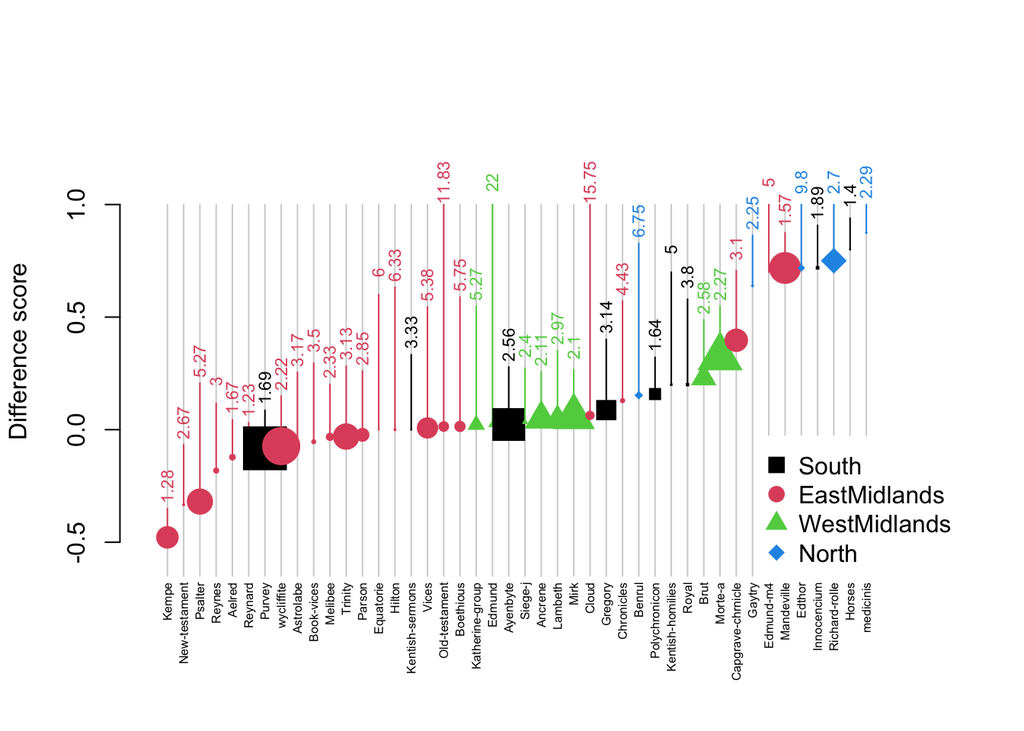

Figure 2.1: Difference score for the texts in the sample; sizes of the dots correspond to the number of observations contributed by the text; vertical bars indicate the overrepresentation of determiners

Using such aggregated data to estimate the parameters of a linear model is unwise. The unweighted model treats each text as contributing the same information, and its main purpose in empirical sciences is to model the distribution of data points, not aggregations.[^8] Thus, the model from the paper makes the assumption that a text with 12 data points (the observed mininum) and a text with 315 data points (the observed maximum) can be treated as contributing the same amount of evidence. This is ill-advised for all types of models, even much simpler ones like the ungrouped average of a population, which is a standard example: Assume we had the task of calculating the average length of a rare kind of newts. Furthermore, assume their true population average length is 10 cm. Because our newts are so rare and difficult to find, instead of going out and measuring a random sample of those rare newts, we look for existing data, finding a report where field researchers measured two newts they found in a pond averaging 7 cm in length and another report from a larger lake where researchers measured the average length of a population of 40 newts to be 10.5 cm. Since the original raw data tables (individual measurements) are not included in the old reports, we average the averages, correctly finding that (7+10.5)/2 is 8.75. While correct, this is certainly not a good estimator of the average length of our newts. It is severly skewed because of the unequal sizes of the samples, and the two newts from the pond receive much too high a weight. Similarly, if *Innocendium* and *Horses* were just as long a text (or as large a sample from a text) as *Purvey* and *Ayenbyte*, all generalisations about the Southern dialect group would disappear.[^9]

In other words, when we specify a model we assume that all kinds of sources influence the variance in the data points, which are assumed to be simple measurements. The model is specified to relate the systematic (explained) influences (variance in the explanatory variables) to the variance in the response variable, leaving the unexplained variance as residuals. However, in this case the difference score is itself an estimate based on wildly varying sample sizes and varying balance between the numbers of adjectives and determiners, which means that it comes with a kind of variance—or rather: inaccuracy—that the simple linear model and its interpretation do not expect (in a technical sense). This also means that actual significance levels very likely do not correspond to nominal significance levels, and using a more rigid significance level than 0.05 would be recommended. The next section shows an alternative model and what remains of the results advertised in the paper after a more accurate modelling.

### 2.1.2 Alternative models

The example given above about the biologists and the length of newts assumed that the original measurements (lengths of individual newts) were lost. This is not the case here, and the original data points are available in the data package. Even in the middle ages, the relevant event was the actual production of a single instance of a determiner or an adjective by a writer. Therefore, the best model for the case at hand is one that estimates the probability of them marking plural agreement or not.[^10] A model that comes close to the idea in the paper is the following one. It models the probability of the realisation of agreement on a word as a function of ist part-of-speech (adjective or determiner), the dialect group, and an interaction between the two.

Table 2.1: The Paper model is a binomial model with a logit link. N=4366, AIC=4681.79, Tjur’s R²=0.1473. The prediction accuracy on the training data (at a probability threshold of 0.5) is 0.75 given a base rate of 0.71.

| Term | Level | Coefficient | Sigma | P | Sig. |
| --- | --- | --- | --- | --- | --- |
| Intercept | (Adjective, South, 0) | 1.96 | 10.72 | <0.0001 | *** |
| POS | Determiner | -0.38 | 1.78 | 0.0752 |  |
| Dialect | WestMidlands | -0.72 | 3.40 | 0.0007 | *** |
|  | EastMidlands | -1.53 | 7.02 | <0.0001 | *** |
|  | North | -0.53 | 1.55 | 0.1216 |  |
| POS:Dialect | Determiner:WestMidlands | 0.52 | 2.12 | 0.0344 | * |
|  | Determiner:EastMidlands | 0.08 | 0.33 | 0.7388 |  |
|  | Determiner:North | -2.52 | 6.47 | <0.0001 | *** |

If we drop the influence of dialect from the model specification, we arrive at a model that—according to standard metrics like R²—is actually worse.

Table 2.2: The Null model is a binomial model with a logit link. N=4366, AIC=5260.12, Tjur’s R²=0.0047. The prediction accuracy on the training data (at a probability threshold of 0.5) is 0.71 given a base rate of 0.71.

| Term | Level | Coefficient | Sigma | P | Sig. |
| --- | --- | --- | --- | --- | --- |
| Intercept | (Adjective) | 1.15 | 16.86 | <0.0001 | *** |
| POS | Determiner | -0.35 | 4.53 | <0.0001 | *** |

Table 2.3: Model comparison for the Null model

| Name | AIC | R2_Tjur | RMSE |
| --- | --- | --- | --- |
| AgreementNullModel | 5260.122 | 0.0047341 | 0.4538269 |
| AgreementPaperModel | 4681.792 | 0.1473388 | 0.4200577 |

Table 2.4: The Text model is a multilevel binomial model with a logit link. N=4366, AIC=3202.59, Conditional R²=0.5781, Marginal R²=0.1546. The prediction accuracy on the training data (at a probability threshold of 0.5) is 0.86 given a base rate of 0.71. The only random effect is Text with 46 levels.

| Term | Level | Coefficient | Sigma | P | Sig. |
| --- | --- | --- | --- | --- | --- |
| Intercept | (Adjective, South, 0) | 1.38 | 2.08 | 0.0374 | * |
| POS | Determiner | -0.50 | 1.98 | 0.0473 | * |
| Dialect | WestMidlands | 1.13 | 1.45 | 0.1458 |  |
|  | EastMidlands | 0.29 | 0.31 | 0.7576 |  |
|  | North | 1.09 | 0.97 | 0.3301 |  |
| POS:Dialect | Determiner:WestMidlands | 0.16 | 0.55 | 0.5800 |  |
|  | Determiner:EastMidlands | -0.63 | 1.95 | 0.0517 |  |
|  | Determiner:North | -3.80 | 7.36 | <0.0001 | *** |

We see immediately that the variation between the texts swamps all other explanatory factors while the overall explanatory power of the model goes up, at least measured in the conditional R²=0.58. The only relevant generalisation that survives at the nominal significance level is the interaction between POSDeterminer and DialectNorth, i.e., writers from the North avoid agreement on determiners more strongly than on adjectives. It should be kept in mind that this generalisation is based on 350 data points from 5 texts spanning a period of 340 years. Regardless of nominal significance, a careful interpretation seems wise. We proceed to a further inspection of the models presented in the next section.

### 2.1.3 Interpretation of the models

Table 2.5: Correct and incorrect predictions of the Paper model

|  | Agreement | No Agreement |
| --- | --- | --- |
| Agreement | 3038 | 1056 |
| No Agreement | 51 | 221 |

The *Null model* with only part-of-speech as a predictor is considerably weaker inasmuch as it always predicts overt agreement and hence does not differentiate at all. However, the *Text model*, which is the one that incorporates a random effect for text, does much better than what was suggested in the paper. Its predictions are correct in 3740 cases and incorrect in 626 cases, i.e., 85.7 %.

Table 2.6: Correct and incorrect predictions of the Text model

|  | Agreement | No Agreement |
| --- | --- | --- |
| Agreement | 2856 | 393 |
| No Agreement | 233 | 884 |

If we look at the numerical probabilities estimated by the Paper model and the Text model for the observed data, we see that the model that accounts for variance between texts (and thus, implicitly, authors), differentiates much better. In the violin plots, the left shape summarises the distribution of probabilities estimated by the model for cases where no overt agreement was observed in the data. The right shape summarises the distribution of probabilities for cases where agreement was overtly realised in the data. Obviously, the Paper model is not even a good model of the data used to estimate its parameters, which means that it is very likely that it does not generalise well to other data. Put differently, we see clear indication that the external validity of the model is low. The Text model fares much better in this respect, but only by acknowledging that the main influencing factor is the text (who wrote the text, under which circumstances, etc.).

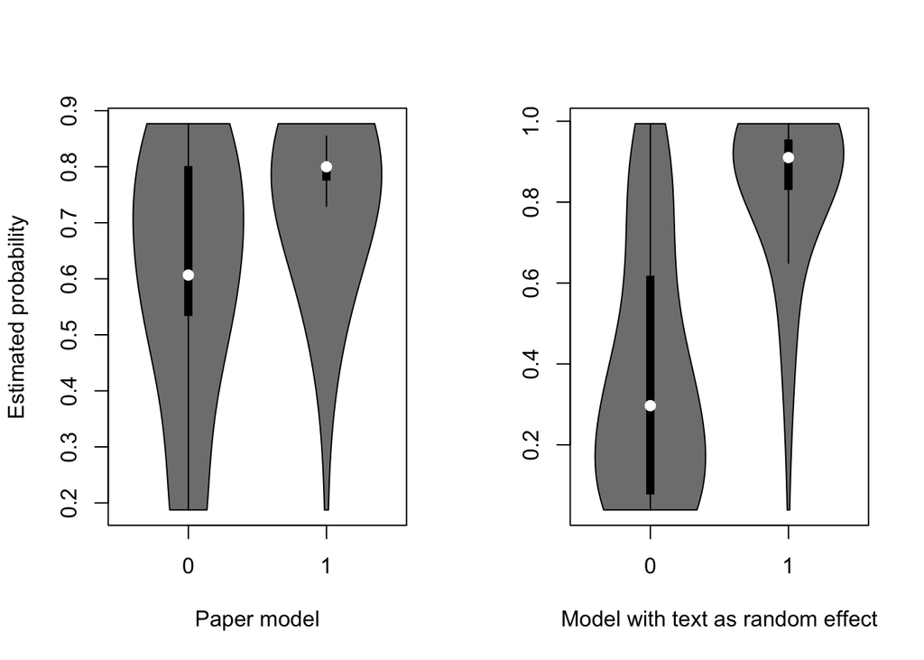

Figure 2.2: Probabilities estimated by the Paper model and the Text model; only for data used to estimate the model parameters and grouped by their actual outcome

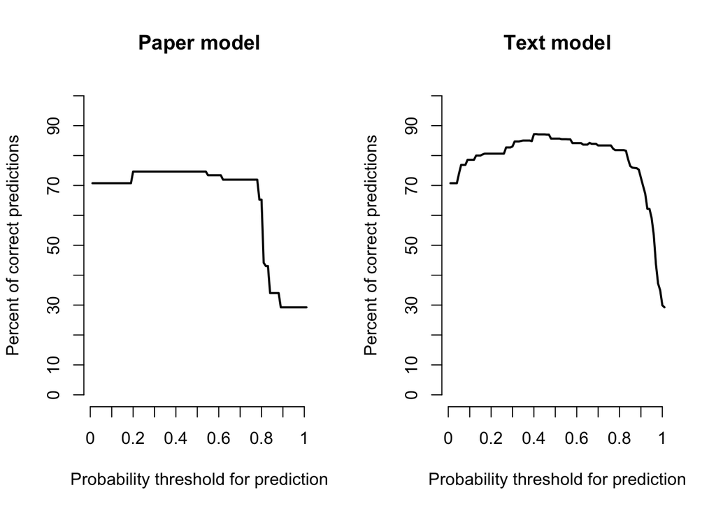

Figure 2.3: Percent of binary predictions based on the Paper model and the Text model at varying theresholds; only for data used to estimate the model parameters and grouped by their actual outcome

Finally, we can approach the accuracy of the model from two other perspectives. The *Precision* is the proportion of correct predictions of the event occurring (here, the subject being overtly realised) among all predictions of this event. In other words, it is the number of true positives divided by all positives (true or false). The *Recall*, on the other hand, is the proportion of correct predictions of the event occurring among all the cases in which the event actually occurred. Put differently, it is the number of true positives divided by the number of events that have occurred. These two scores, evaluated at different thresholds, can be used to assess the quality of the model and adjust the threshold. The balanced point (where Precision and Recall reach their highest values and the curves cross) is around 80 % for the Paper model and around 90 % for the Text model, which is another indicator that the Text model differentiates much better.

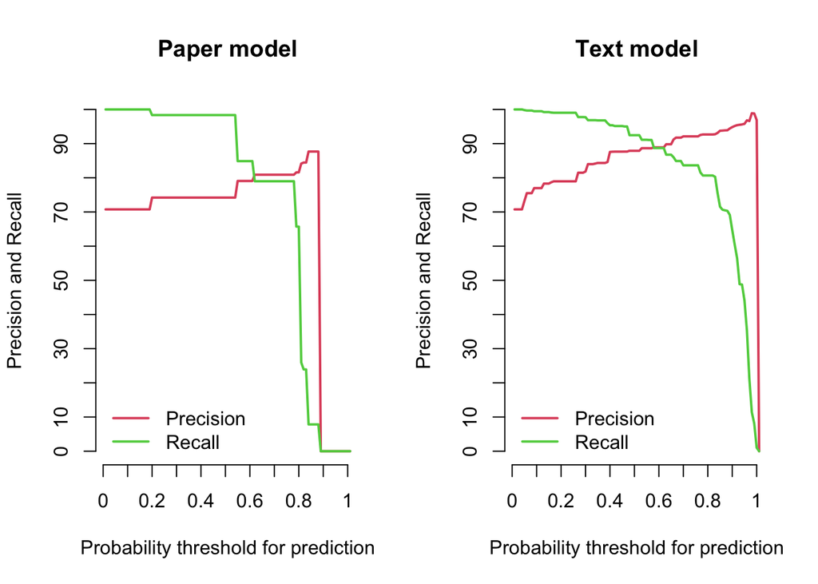

Figure 2.4: Precision and Recall for the Paper model and the Text model at varying theresholds; only for data used to estimate the model parameters and grouped by their actual outcome

## 2.2 Study 2: Null subjects in Spanish

### 2.2.1 What was reported

In Study 2, the authors set out to model the influence of orality, time, and region (Spain versus Latin American countries) on the tendency to use overt subjects in Spanish despite the overall very strong tendency towards subject drop in Spanish. Orality is measured as the ORScore, which appears to be an aggregate relative frequency of certain grammatical features in the respective texts. It is thus based on a derived construct and not on direct observations. Given the fact that it is composed of proportions (relative frequencies) the warnings raised in the previous section apply here as well. Here is the report of the model fit from the paper, where `Subject` is 1 for an observation with an overt subject, `ORScoreZ` is the z-transformed orality score, `YearZ` is the z-transformed year the respective document was dated at, and `Macroregion` is Spain or Non-Spain. The random effect `Text` has 37 levels for 37 documents. Henceforth, we shall call this the *Paper model*.

Table 2.7: The Paper model is a multilevel binomial model with a logit link. N=3773, AIC=2548.2, Conditional R²=0.2063, Marginal R²=0.1311. The prediction accuracy on the training data (at a probability threshold of 0.5) is 0.89 given a base rate of 0.89. The only random effect is Text with 37 levels.

| Term | Level | Coefficient | Sigma | P | Sig. |
| --- | --- | --- | --- | --- | --- |
| Intercept | (0, 0, Spain) | -2.55 | 9.24 | <0.0001 | *** |
| ORScoreZ |  | 1.03 | 3.82 | 0.0001 | *** |
| YearZ |  | 0.05 | 0.33 | 0.7435 |  |
| Macroregion | Non-Spain | 0.63 | 1.96 | 0.0495 | * |
| ORScoreZ:YearZ |  | -0.44 | 2.12 | 0.0342 | * |

### 2.2.2 Alternative models

We begin by comparing the Paper model to the *Null model*, which is a model that only has a fixed intercept and a random intercept for the text. In other words, we allow the intercept to vary between groups of data points defined by the texts they occur in, and no other explanatory variables are included. The Null model is a multilevel binomial model with a logit link. N=3773, AIC=2562.62, Conditional R²=0.1835, Marginal R²=0. The prediction accuracy on the training data (at a probability threshold of 0.5) is 0.89 given a base rate of 0.89. The only random effect is Text with 37 levels. The AIC of the Paper model is slighlty lower. The marginal R² of the Null model is of course 0, as there are no first-level fixed effects, but even the conditional R² of the Paper model is minimally higher than that of the Null model. All in all, it does not appear even from this simple evaluation as if the orality score, the macroregion, and the date of the document explain much of the variance in the data.

A second alternative model we would like to entertain is given below as the *Country-Genre model*. It drops the alleged main explanatory regressor (orality), the secondary one (year), and it used the country and the genre as fixed effects instead. Contrary to the quote from the paper, the model converges, and the country regressor does not have too many levels.[^14]

Table 2.8: The Country-Genre model is a multilevel binomial model with a logit link. N=3773, AIC=2566.93, Conditional R²=0.1853, Marginal R²=0.0465. The prediction accuracy on the training data (at a probability threshold of 0.5) is 0.89 given a base rate of 0.89. The only random effect is Text with 37 levels.

| Term | Level | Coefficient | Sigma | P | Sig. |
| --- | --- | --- | --- | --- | --- |
| Intercept | (Spain, Nonliterary) | -2.79 | 7.61 | <0.0001 | *** |
| Country | Bolivia | 0.32 | 0.64 | 0.5212 |  |
|  | Colombia | -0.12 | 0.28 | 0.7797 |  |
|  | Dominican Republic | 0.02 | 0.04 | 0.9669 |  |
|  | Panamá | 0.28 | 0.59 | 0.5531 |  |
| Genre | Literary | 0.27 | 0.86 | 0.3885 |  |
|  | Supplemental | 1.31 | 2.53 | 0.0115 | * |

Table 2.9: Model comparison for the Country-Genre model

| Name | AIC | R2_conditional | R2_marginal |
| --- | --- | --- | --- |
| SubjectCountryGenreModel | 2566.931 | 0.1852888 | 0.0465148 |
| SubjectPaperModel | 2548.202 | 0.2063281 | 0.1310736 |

We see that the Country-Genre model is also slightly worse than the Paper model. It is unclear, however, why the authors claim that the country regressor was impossible to add for technical reasons. The estimator has no trouble estimating the coefficients, they just don’t reach the nominal significance level of 0.05.

We proceed to estimating the parameters of a more complex model. The *Full-Country model* is the Paper model including orality and year as regressors but with country instead of macroregion and additionally genre as fixed effects.

Table 2.10: The Full-Country model is a multilevel binomial model with a logit link. N=3773, AIC=2555.6, Conditional R²=0.2097, Marginal R²=0.1406. The prediction accuracy on the training data (at a probability threshold of 0.5) is 0.89 given a base rate of 0.89. The only random effect is Text with 37 levels.

| Term | Level | Coefficient | Sigma | P | Sig. |
| --- | --- | --- | --- | --- | --- |
| Intercept | (0, 0, Spain, DOC) | -2.62 | 8.54 | <0.0001 | *** |
| ORScoreZ |  | 1.12 | 3.75 | 0.0002 | *** |
| YearZ |  | -0.06 | 0.33 | 0.7401 |  |
| Country | Bolivia | 0.96 | 2.05 | 0.0400 | * |
|  | Colombia | 0.68 | 1.61 | 0.1067 |  |
|  | Dominican Republic | 0.39 | 0.99 | 0.3213 |  |
|  | Panamá | 0.51 | 1.30 | 0.1924 |  |
| Genre | Literary | 0.20 | 0.78 | 0.4367 |  |
|  | Supplemental | 0.28 | 0.56 | 0.5785 |  |
| ORScoreZ:YearZ |  | -0.58 | 2.45 | 0.0143 | * |

Table 2.11: Model comparison for the Full-Country model

| Name | AIC | R2_conditional | R2_marginal |
| --- | --- | --- | --- |
| SubjectFullCountryModel | 2555.599 | 0.2097230 | 0.1405899 |
| SubjectPaperModel | 2548.202 | 0.2063281 | 0.1310736 |

The Full-Country model performs slightly better than the Paper model in terms of the R². It should, however, have become clear by now that the slightly varying conditional R² coefficients are merely an artefact due to the shifting marginal R² coefficients. Additionally, we observe that country has only one level (Bolivia) that is sufficiently distinct from the intercept value (Spain) to reach the nominal significance level. Concluding from the data presented in the paper that “overtness [is favoured] in every country but Spain” is thus not warranted, even under an NHST umbrella. If we drop genre, the picture changes again with the *Full-No-Genre model*.

Table 2.12: The Full-No-Genre model is a multilevel binomial model with a logit link. N=3773, AIC=2552.27, Conditional R²=0.2107, Marginal R²=0.1391. The prediction accuracy on the training data (at a probability threshold of 0.5) is 0.89 given a base rate of 0.89. The only random effect is Text with 37 levels.

| Term | Level | Coefficient | Sigma | P | Sig. |
| --- | --- | --- | --- | --- | --- |
| Intercept | (0, 0, Spain) | -2.52 | 9.26 | <0.0001 | *** |
| ORScoreZ |  | 1.15 | 3.89 | 0.0001 | *** |
| YearZ |  | -0.04 | 0.23 | 0.8175 |  |
| Country | Bolivia | 0.99 | 2.14 | 0.0321 | * |
|  | Colombia | 0.76 | 2.02 | 0.0437 | * |
|  | Dominican Republic | 0.40 | 1.02 | 0.3081 |  |
|  | Panamá | 0.53 | 1.36 | 0.1741 |  |
| ORScoreZ:YearZ |  | -0.56 | 2.38 | 0.0173 | * |

Table 2.13: Model comparison for the Full-No-Genre model

| Name | AIC | R2_conditional | R2_marginal |
| --- | --- | --- | --- |
| SubjectFullNoGenreModel | 2552.271 | 0.2106704 | 0.1390568 |
| SubjectPaperModel | 2548.202 | 0.2063281 | 0.1310736 |

We see that model specification is not an exact art. Dropping genre as a regressor leads to Columbia also reaching the nominal significance level. Based on NHST logic, it is now Spain, the Dominican Republic, and Panamá versus Bolivia and Columbia. Regarding the R², the various model specifications do not seem to change by any considerable margin. In the next section, we show why.

### 2.2.3 Interpretation of the models

As explained in the discussion of Study 1, we check the probability estimates that the model makes on the data used to estimate its parameters. First, we examine the correct binary predictions using a 0.5 probability threshold. The model predicts a null subject in 3773 cases and a pronominal subject in 0 cases. In other words, it predicts that there should never be an overt subject. This is due to the obviously uninformative regressors and the high base rate. The base rate (no overt subject) is at 88.55 %. To see whether the Paper model could make better binary predictions with a lower probability threshold for binary decisions, we plot the predictions of the Paper model and the Null model next to each other as violin plots.

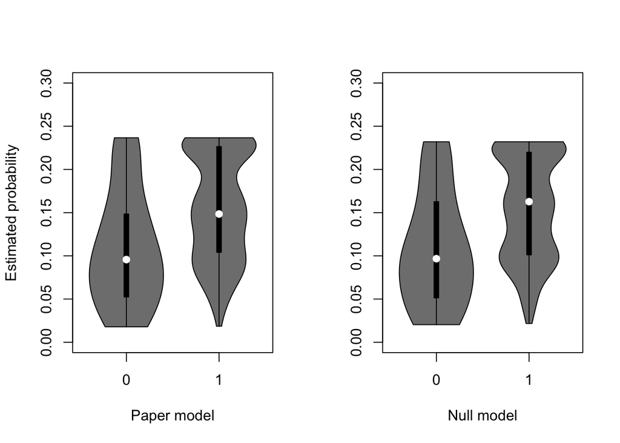

Figure 2.5: Probabilities estimated by the Paper model and the Null model; only for data used to estimate the model parameters and grouped by their actual outcome

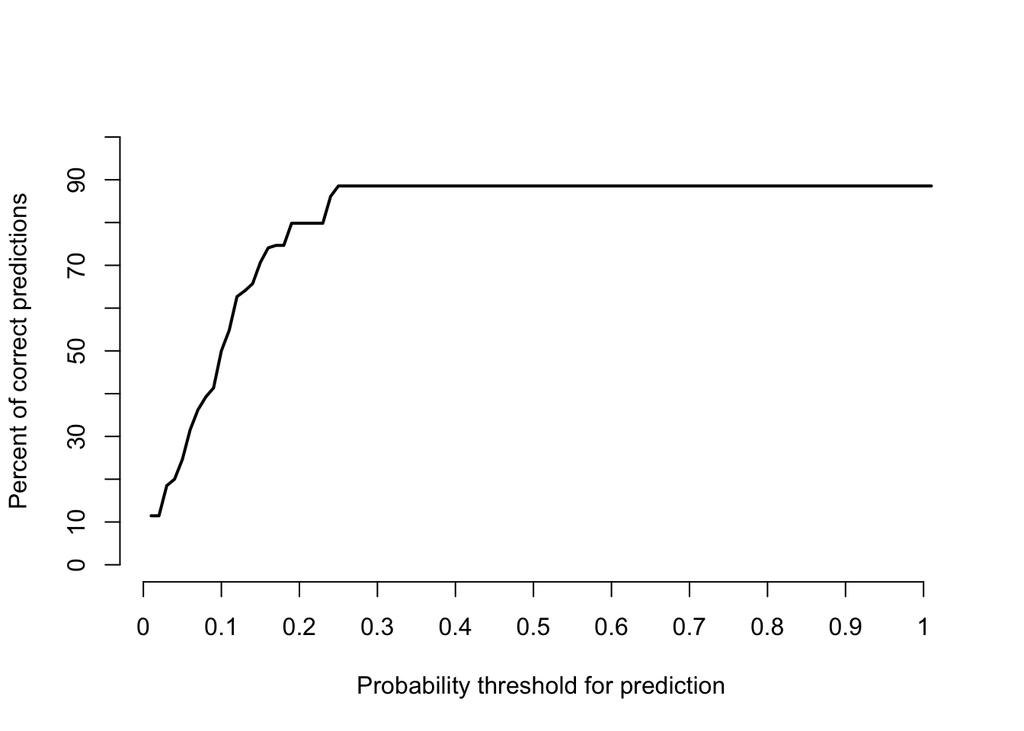

Figure 2.6: Percent of binary predictions based on the Paper model at varying theresholds; only for data used to estimate the model parameters and grouped by their actual outcome

To conclude, here are the Precision and Recall curves for the Paper model. Since the model does not predict any probabilities above 0.24, both precision and recall cannot be higher than 0 past this threshold.

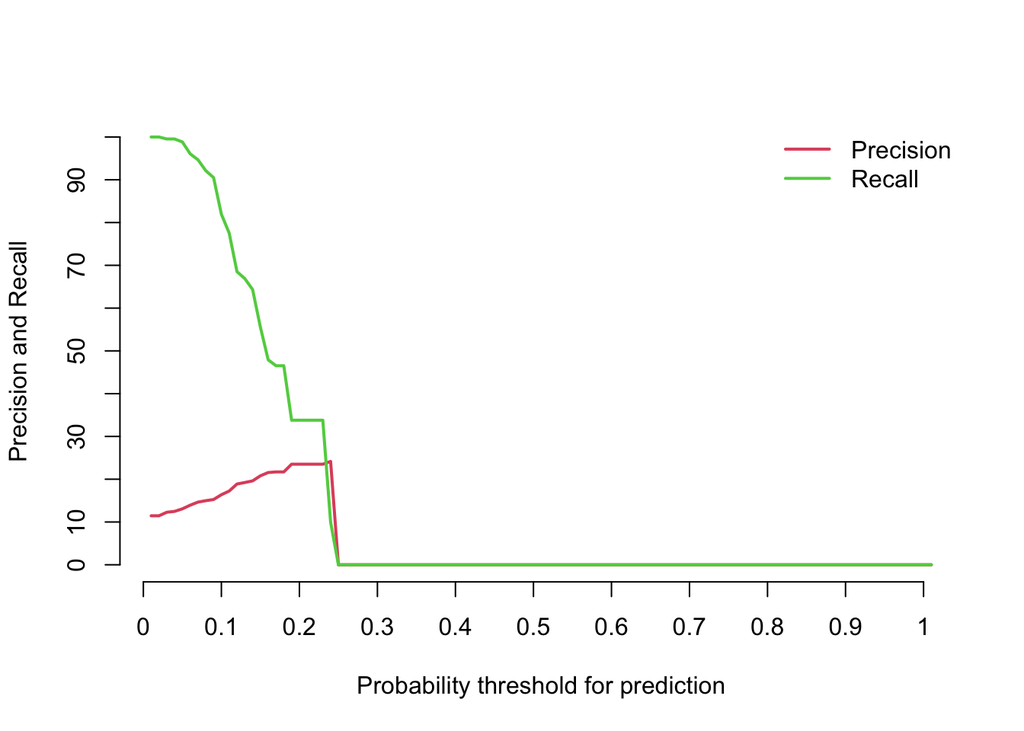

Figure 2.7: Precision and Recall for the Paper model at varying theresholds; only for data used to estimate the model parameters and grouped by their actual outcome

Finally, and most revealing perhaps, we plot the probabilities estimated under the Paper model against the null model.

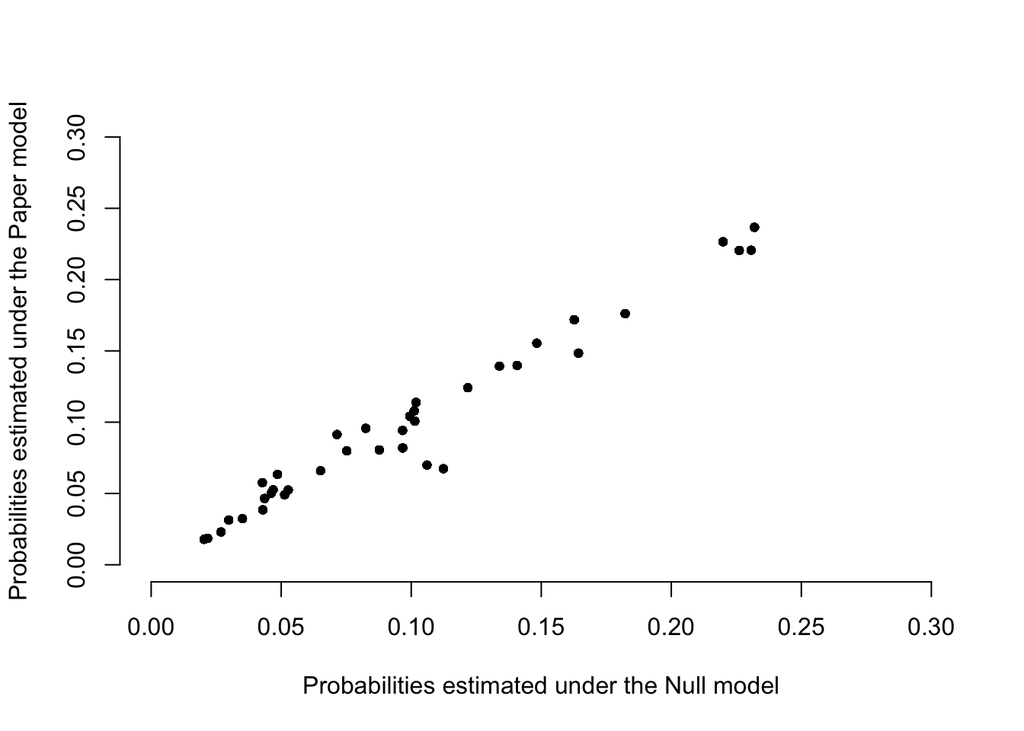

Figure 2.8: Comparing the predictions of the Paper model and the Null model

The plot show which probability the two models estimate for each of the 3,773 observed data points, each data point being plotted as a dot. If the two models made exactly the same estimates, there should be a straight line. We see dots virtually along a straight line with negligeable deviations. The models contain virtually the same information, and the mean absolute difference between the predictions by the two models is 0.0069, the maximal difference is 0.045.

Furthermore and most crucially, we see only 37 dots, not 3,773. This is because within one text, the model makes exactly the same predictions for each data point, and the dots are printed on top of each other. The model shows that documents are different, nothing more. It does not at all “confirm any relationships across countries and centuries” (see above). These problems are not at all hard to pinpoint with full access to the data, and is peculiar that the analysis went on to submission in a paper.[^15] In the remainder of the paper, we discuss what all this means for substantive hypotheses put forward in Walkden et al. (2023) and the field in general.

## 2.3 What was actually found out

# 3 Putting data to good use

…

…

# References

Baayen, R. Harald. 2008. *Analyzing Linguistic Data: A Practical Introduction to Statistics Using R*. Cambridge: Cambridge University Press. https://doi.org/10.1017/cbo9780511801686.

Bresnan, Joan, Anna Cueni, Tatiana Nikitina, and R. Harald Baayen. 2007. “Predicting the Dative Alternation.” In *Cognitive Foundations of Interpretation*, edited by Gerlof Bouma, Irene Krämer, and Joost Zwarts, 69–94. Amsterdam: Koninklijke Nederlandse Akadmie van Wetenschappen.

Fahrmeir, Ludwig, Thomas Kneib, Stefan Lang, and Brian Marx. 2013. *Regression – Models, Methods, and Application*. Berlin etc.: Springer. https://doi.org/10.1007/978-3-642-34333-9_2.

Fisher, Ronald A. 1935. “The Logic of Inductive Inference.” *Journal of the Royal Statistical Society* 98 (1): 39–82. https://doi.org/10.2307/2342435.

———. 1959. *Statistical Methods and Scientific Inference*. 2nd ed. Edinburgh: Oliver; Boyd. https://doi.org/10.2307/2333276.

Gelman, Andrew, and Jennifer Hill. 2006. *Data Analysis Using Regression and Multilevel/Hierarchical Models*. Cambridge: Cambridge University Press. https://doi.org/10.1017/cbo9780511790942.

Gigerenzer, Gerd. 2004. “Mindless Statistics.” *The Journal of Socio-Economics* 33: 587–606. https://doi.org/10.1016/j.socec.2004.09.033.

Greenland, Sander, Stephen J. Senn, Kenneth J. Rothman, John B. Carlin, Charles Poole, Steven N. Goodman, and Douglas G. Altman. 2016. “Statistical Tests, P Values, Confidence Intervals, and Power: A Guide to Misinterpretations.” *European Journal of Epidemiology* 31: 337–50. https://doi.org/10.1007/s10654-016-0149-3.

Gries, Stefan Th. 2013. *Statistics for Linguistics with r: A Practical Introduction*. 2nd ed. Berlin, New York: de Gruyter Mouton. https://doi.org/10.1515/9783110307474.

———. 2015. “The Most Underused Statistical Method in Corpus Linguistics: Multi-Level (and Mixed-Effects) Models.” *Corpora* 10 (1): 95–126. https://doi.org/10.3366/cor.2015.0068.

Ioannidis, John P. A. 2005. “Why Most Published Research Findings Are False.” *PLos Med* 2 (8): e124. https://doi.org/10.1080/09332480.2005.10722754.

Lehmann, Erich L. 2011. *Fisher, Neyman, and the Creation of Classical Statistics*. New York, NY: Springer.

Mayo, Deborah G. 2018. *Statistical Inference as Severe Testing: How to Get Beyond the Statistics Wars*. Cambridge: Cambridge University Press.

Munafò, Marcus R., Brian A. Nosek, Dorothy V. M. Bishop, Katherine S. Button, Christopher D. Chambers, Nathalie Percie du Sert, Uri Simonsohn, Eric-Jan Wagenmakers, Jennifer J. Ware, and John P. A. Ioannidis. 2017. “A Manifesto for Reproducible Science.” *Nature Human Behaviour*, 0021 EP. https://doi.org/10.1038/s41562-016-0021.

Neyman, Jerzy. 1937. “Outline of a Theory of Statistical Estimation Based on the Classical Theory of Probability.” *Philosophical Transactions of the Royal Society A* 236 (767): 333–79. https://doi.org/10.1098/rsta.1937.0005.

———. 1957. “‘Inductive Behavior’ as a Basic Concept of Philosophy of Science.” *Review of the International Statistical Institute* 25 (1): 7–22. https://doi.org/10.2307/1401671.

Neyman, Jerzy, and Egon S. Pearson. 1933. “On the Problem of the Most Efficient Tests of Statistical Hypotheses.” *Philosophical Transactions of the Royal Society A* 231: 694–706. https://doi.org/10.1007/978-1-4612-0919-5_6.

Perezgonzalez, Jose D. 2015. “Fisher, Neyman-Pearson or NHST? A Tutorial for Teaching Data Testing.” *Frontiers in Psychology* 6 (223): 1–11. https://doi.org/10.3389/fpsyg.2015.00223.

Trudgill, Peter. 2011. *Sociolinguistic Typology: Social Determinants of Linguistic Complexity*. Oxford: Oxford University Press.

Walkden, George, Gemma Hunter McCarley, Raquel Montero, Molly Rolf, Sarah Einhaus, and Henri Kauhanen. 2023. “Sociolinguistic Typology Meets Historical Corpus Linguistics.” *Transactions of the Philological Society* 121 (3): 546–67. https://doi.org/10.1111/1467-968X.12275.